# Sentiment analysis with Naive Bayes Vs LSTM keras model

# Introduction

In this project we will compare two methods of sentiment analysis:

The prediction of Negative/Positive using a simple Naïve Bayes model

The prediction of Negative/Positive using a LSTM kera model

The dataset is twitter post with label : 'neutral', 'negative', 'positive'  
in this project, we will do many functions handy to understand how they work

1. Introduction
2. Libraries
3. Dataset
4. WordCloud
5. Naive Bayes classifie
6. LSTM (Long Short-Term Memory)
7. Conclusion

# Libraries

```python
import pandas as pd
import re, string
import numpy as np
import random

import sys
import copy

from wordcloud import WordCloud
import matplotlib.pyplot as plt
import plotly.express as px

import keras
import tensorflow as tf
from tensorflow.keras.layers import Embedding
from tensorflow.keras.layers import Input
from keras.models import Model
from keras.layers import Dense, Input, Dropout, LSTM, Activation
from keras.preprocessing import sequence
from keras.initializers import glorot_uniform
from keras.models import load_model
```

# Dataset

The dataset is available in kaggle (link below)  
In this application we will download train and test datasets

https://www.kaggle.com/datasets/abhi8923shriv/sentiment-analysis-dataset

#### Train dataset

```python
file=r"train.csv"
df1 = pd.read_csv(file, engine='python', encoding = 'ISO-8859-1')
df1.head(3)
```

|  | textID | text | selected_text | sentiment | Time of Tweet | Age of User | Country | Population -2020 | Land Area (Km²) | Density (P/Km²) |
| --- | --- | --- | --- | --- | --- | --- | --- | --- | --- | --- |
| 0 | cb774db0d1 | I`d have responded, if I were going | I`d have responded, if I were going | neutral | morning | 0-20 | Afghanistan | 38928346 | 652860.0 | 60 |
| 1 | 549e992a42 | Sooo SAD I will miss you here in San Diego!!! | Sooo SAD | negative | noon | 21-30 | Albania | 2877797 | 27400.0 | 105 |
| 2 | 088c60f138 | my boss is bullying me... | bullying me | negative | night | 31-45 | Algeria | 43851044 | 2381740.0 | 18 |

#### Test dataset

```python
file=r"test.csv"
df2 = pd.read_csv(file, engine='python', encoding = 'ISO-8859-1')
df2.head(3)
```

|  | textID | text | sentiment | Time of Tweet | Age of User | Country | Population -2020 | Land Area (Km²) | Density (P/Km²) |
| --- | --- | --- | --- | --- | --- | --- | --- | --- | --- |
| 0 | f87dea47db | Last session of the day http://twitpic.com/67ezh | neutral | morning | 0-20 | Afghanistan | 38928346.0 | 652860.0 | 60.0 |
| 1 | 96d74cb729 | Shanghai is also really exciting (precisely -... | positive | noon | 21-30 | Albania | 2877797.0 | 27400.0 | 105.0 |
| 2 | eee518ae67 | Recession hit Veronique Branquinho, she has to... | negative | night | 31-45 | Algeria | 43851044.0 | 2381740.0 | 18.0 |

Dim of each dataset

```python
len(df1),len(df2)
```

```
(27481, 4815)
```

#### Merge both datasets and chose only text and sentiment columns

```python
df=pd.concat([df1[['text','sentiment']],df2[['text','sentiment']]],axis=0).dropna().reset_index(drop=True)#
df.head()
```

|  | text | sentiment |
| --- | --- | --- |
| 0 | I`d have responded, if I were going | neutral |
| 1 | Sooo SAD I will miss you here in San Diego!!! | negative |
| 2 | my boss is bullying me... | negative |
| 3 | what interview! leave me alone | negative |
| 4 | Sons of ****, why couldn`t they put them on t... | negative |

### Input text

```python
X=df.text.values
```

```python
X
```

```
array([' I`d have responded, if I were going',
       ' Sooo SAD I will miss you here in San Diego!!!',
       'my boss is bullying me...', ...,
       ' I know what you mean. My little dog is sinking into depression... he wants to move someplace tropical',
       '_sutra what is your next youtube video gonna be about? I love your videos!',
       ' http://twitpic.com/4woj2 - omgssh  ang cute ng bby.!'],
      dtype=object)
```

#### Collecting the punctuation characters

```python
# collect all punctuation
t=''
for o in X:
    t=t+' '+o
l=[]
for o in t:
    if ord(o) <  ord('0') or ( ord(o) > ord('9')  and  ord(o) < ord('A') ) or (ord(o) > ord('Z')  and ord(o) < ord('a')) or ord(o) > ord('z'):
    # Keep only caracter between [0,9] and [A,Z] and [a,z]
        l.append(o)
l=set(l)
print(l)
print(''.join(l).replace(' ',''))
```

```
{'@', '!', '´', '\\', ':', '&', '½', '\x82', 'Ã', '%', '¡', ')', '#', ' ', ';', '*', '`', '~', '+', '¯', '}', '(', '<', '[', '?', 'Â', '$', "'", '¿', '|', '\t', '{', '=', '/', '-', '^', '_', '\xa0', '>', '.', ',', ']'}
@!´\:&½Ã%¡)#;*`~+¯}(<[?Â$'¿|	{=/-^_ >.,]
```

#### Removing the punctuation

```python
def process_string(X):
    ################ Remove punctuation####################
     # use this string as separation between X elements
    sep='28487612184'
    # converting X array to one string
    s=str(sep).join(X)
    # use the punctuation collected above
    punctuation='''\xa0Â\t<¯]&*`)¿_|$;Ã?}½{´.@+\\-¡%>#\x82/^(:![=~',"'''
    #remove punctuation
    out = re.sub('[%s]' % re.escape(punctuation), ' ', s)
    ############## Lower the text ##########################
    out=out.lower()
    ############## Remove multiple space ##################
    out=re.sub(' +', ' ', out)
    ############# convert out to array and remove begenning and end space of each elements
    #convert out to array
    out=np.array(out.split(sep)).astype(str)
    # removing the begen and the end space of each elements
    out = np.char.strip(out)
    return out
```

```python
# remind the initial input
X
```

```
array([' I`d have responded, if I were going',
       ' Sooo SAD I will miss you here in San Diego!!!',
       'my boss is bullying me...', ...,
       ' I know what you mean. My little dog is sinking into depression... he wants to move someplace tropical',
       '_sutra what is your next youtube video gonna be about? I love your videos!',
       ' http://twitpic.com/4woj2 - omgssh  ang cute ng bby.!'],
      dtype=object)
```

##### Processing the input by the above function

```python
# Processing the input by the above funcition
Xp=process_string(X)
Xp
```

```
array(['i d have responded if i were going',
       'sooo sad i will miss you here in san diego',
       'my boss is bullying me', ...,
       'i know what you mean my little dog is sinking into depression he wants to move someplace tropical',
       'sutra what is your next youtube video gonna be about i love your videos',
       'http twitpic com 4woj2 omgssh ang cute ng bby'], dtype='<U137')
```

### Output sentiment

##### keep only unique sentiment

```python
df.sentiment.unique()
```

```
array(['neutral', 'negative', 'positive'], dtype=object)
```

#### replace string sentiment by integers: 'neutral':0, 'negative':-1, 'positive':1

```python
#initial sentiment
Y=df.sentiment
Y.head(7)
```

```
0     neutral
1    negative
2    negative
3    negative
4    negative
5     neutral
6    positive
Name: sentiment, dtype: object
```

##### After replacing string

```python
Y=Y.replace({'neutral':0, 'negative':-1, 'positive':1}).values
Y[:7]
```

```
array([ 0, -1, -1, -1, -1,  0,  1], dtype=int64)
```

### Preparing train set and validation set

In general, we split the available data to:

* Train set: used to train the models  
* Developpement set : used to tune the models  
* Test set: use to validate the model after tuning, In the actual project we will call it Validation set to use just "t" for train and "v" for validation  
In the actual example, we will split data to only train/validation set

##### Shuffling the data

```python
#Shuffling the index
index=list(range(len(Y)))
random.shuffle(index)
```

```python
#shuffle the data
Xs=np.array([Xp[i] for i in index])
Ys=np.array([Y[i] for i in index])
```

##### Train vs validation set

```python
# the ration of train/all data
ratio_train_val=0.9
N=len(Xs)
# Train set
Xt=Xs[:int(N*ratio_train_val)]
Yt=Ys[:int(N*ratio_train_val)]
# Validation set
Xv=Xs[int(N*ratio_train_val):]
Yv=Ys[int(N*ratio_train_val):]
```

##### Verification of the shapes

```python
Xp.shape,Xs.shape,Xt.shape,Xv.shape
```

```
((31014,), (31014,), (27912,), (3102,))
```

##### The train is 90% of all data, the validation set is 10% of the available data

```python
len(Xt)/len(Xp),len(Xv)/len(Xp)
```

```
(0.8999806538982396, 0.1000193461017605)
```

```python
len(Yt)/len(Y),len(Yv)/len(Y)
```

```
(0.8999806538982396, 0.1000193461017605)
```

### removing the neutral sentiment

The above classe work only by positive/negative sentiment +1/-1

```python
filter_neut_train=Yt!=0
Xtpn=Xt[filter_neut_train]
Ytpn=Yt[filter_neut_train]
filter_neut_val=Yv!=0
Xvpn=Xv[filter_neut_val]
Yvpn=Yv[filter_neut_val]
```

```python
Xtpn
```

```
array(['happy mother s day hugs',
       'omg great day today went to a art thingy and noe i really want a zune hd and the bed part its raining come out mister sun',
       'oh that s cool thanks', ...,
       'oh i hella forgot to say my official good morning like to hear it here it go goooooooooooood morrrrrrrrning twitterville lol',
       'glad you got there safe saw your daughter enjoy your time there',
       'you too sweetie'], dtype='<U137')
```

```python
Ytpn
```

```
array([1, 1, 1, ..., 1, 1, 1], dtype=int64)
```

### GloVe: Global Vectors for Word Representation

The idea is to code each word of english with a velcor of n elements, in the actual example n=50 and the dictionnary has 400k words

You can download the glove.6B.50d.txt dictionnary at the link  
https://www.kaggle.com/datasets/watts2/glove6b50dtxt

We can use **Word2vec** intead of GloVe, below the differnece between theme that we can found in internet: [her](https://machinelearninginterview.com/topics/natural-language-processing/what-is-the-difference-between-word2vec-and-glove/#:~:text=Glove%20model%20is%20based%20on,similar%20results%20for%20many%20tasks)

Glove model is based on leveraging global word to word co-occurance counts leveraging the entire corpus. Word2vec on the other hand leverages co-occurance within local context (neighbouring words)

```python
file=r"C:\Users\a037702\OneDrive - Alliance\00_DATA_SCIENCE\10_personnel\01_sentiment_anal_data\glove.6B.50d.txt"
def read_glov(file):
    df = pd.read_csv(file, sep=" ", quoting=3, header=None, index_col=0)
    Glove= {key: val.values for key, val in df.T.items()}
    return Glove
Glove= read_glov(file)
```

Example of word embedding of 'i'

```python
Glove['i']
```

```
array([ 1.1891e-01,  1.5255e-01, -8.2073e-02, -7.4144e-01,  7.5917e-01,
       -4.8328e-01, -3.1009e-01,  5.1476e-01, -9.8708e-01,  6.1757e-04,
       -1.5043e-01,  8.3770e-01, -1.0797e+00, -5.1460e-01,  1.3188e+00,
        6.2007e-01,  1.3779e-01,  4.7108e-01, -7.2874e-02, -7.2675e-01,
       -7.4116e-01,  7.5263e-01,  8.8180e-01,  2.9561e-01,  1.3548e+00,
       -2.5701e+00, -1.3523e+00,  4.5880e-01,  1.0068e+00, -1.1856e+00,
        3.4737e+00,  7.7898e-01, -7.2929e-01,  2.5102e-01, -2.6156e-01,
       -3.4684e-01,  5.5841e-01,  7.5098e-01,  4.9830e-01, -2.6823e-01,
       -2.7443e-03, -1.8298e-02, -2.8096e-01,  5.5318e-01,  3.7706e-02,
        1.8555e-01, -1.5025e-01, -5.7512e-01, -2.6671e-01,  9.2121e-01])
```

##### Number of word in the dictionnary : ~400k words

```python
len(Glove)
```

```
399998
```

##### We can calculate similarity between vector as below by GloVe dictionary

We use a simple linear norm of numpy to calculate the distance between each couple of words

```python
np.linalg.norm(Glove['man']-Glove['woman'])
```

```
2.602623583218169
```

```python
np.linalg.norm(Glove['man']-Glove['dog'])
```

```
3.849004774547739
```

The word "man" is close to "woman" more than to "dog"

#### Save processed data

```python
np.savez_compressed('Processed_data.npz',Xp=Xp,Xt=Xt,Xv=Xv,Xtpn=Xtpn,Xvpn=Xvpn,Y=Y,Yt=Yt,Yv=Yv,Yvpn=Yvpn,Ytpn=Ytpn)
```

##### Save also the GloVe dcitonary

```python
np.savez_compressed('Glove.npz',Glove=Glove)
```

```python
print(Xp.shape,Xt.shape,Xv.shape,Xtpn.shape,Xvpn.shape,Y.shape,Yt.shape,Yv.shape,Yvpn.shape,Ytpn.shape,len(Glove))
```

```
(31014,) (27912,) (3102,) (16599,) (1868,) (31014,) (27912,) (3102,) (1868,) (16599,) 399998
```

#### Read processed data

```python
loaded = np.load('Processed_data.npz',allow_pickle=True)
Xp=loaded['Xp']
Xt=loaded['Xt']
Xv=loaded['Xv']
Xtpn=loaded['Xtpn']
Xvpn=loaded['Xvpn']
Y=loaded['Y']
Yt=loaded['Yt']
Yv=loaded['Yv']
Ytpn=loaded['Ytpn']
Yvpn=loaded['Yvpn']
```

##### Load also the GloVe dcitonary

```python
loaded = np.load('Glove.npz',allow_pickle=True)
Glove=loaded['Glove'].tolist()
```

```python
print(Xp.shape,Xt.shape,Xv.shape,Xtpn.shape,Xvpn.shape,Y.shape,Yt.shape,Yv.shape,Yvpn.shape,Ytpn.shape,len(Glove))
```

```
(31014,) (27912,) (3102,) (16599,) (1868,) (31014,) (27912,) (3102,) (1868,) (16599,) 399998
```

# WordCloud

##### Separte positive and negative text

```python
# filters
fp=Y==1
fn=Y==-1
# Join Positive/Negative input in one string
Input_Pos=' '.join(Xp[fp].tolist())
Input_Neg=' '.join(Xp[fn].tolist())
```

##### Define the excluded words

```python
exclude_words='and in my i m it the for is on you abut with of me a that was s all but just so have day to this one now sheget out at am they im do up she from'
# split the words with spaces
exclude_words=exclude_words.split(' ')
```

##### WordCloud of positive posts

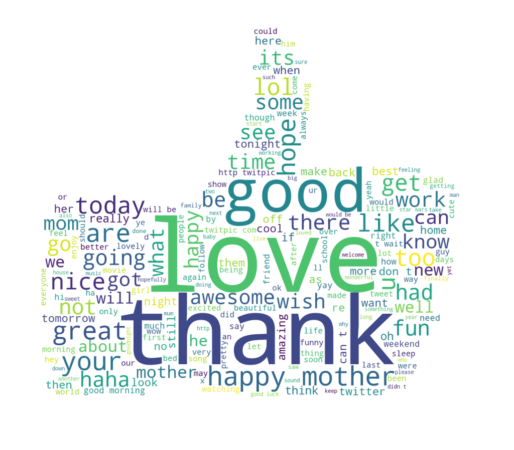

```python
# read the mask
MASK =np.array(Image.open('like_mask.png'))
# make the wordcloud
wordcloud = WordCloud(background_color = 'white', stopwords = exclude_words,width=1000,height=500,mask=MASK).generate(Input_Pos)
# plot the wordcloud
plt.figure(figsize=(16, 12))
plt.imshow(wordcloud)
plt.axis("off")
plt.savefig('positive_inp.png')
plt.show();
```

##### WordCloud of negative posts

[figure not shown]

```python
MASK =np.array(Image.open('dislike_mask.png'))
wordcloud = WordCloud(background_color = 'white', stopwords = exclure_mots,width=1000,height=500,mask=MASK).generate(Input_Neg)
plt.figure(figsize=(16, 12))
plt.imshow(wordcloud)
plt.axis("off")
plt.savefig('negative_inp.png')
plt.show();
```

____

# Naive Bayes classifier

### wiki definition

In statistics, naive Bayes classifiers are a family of simple "probabilistic classifiers" based on applying Bayes' theorem with strong (naive) independence assumptions between the features (see Bayes classifier). They are among the simplest Bayesian network models,[1] but coupled with kernel density estimation, they can achieve high accuracy levels.  
For more information see wikipedia link:

https://en.wikipedia.org/wiki/Naive_Bayes_classifier

### The Naive Bytes class

Below the class of Naive Bayes classifier, the class functions will be explained one by one after the class code

```python
class NaiveBytes():
    def __init__(self):
        self.logprior=None
        self.list_rem='''! ( ) - [ ] { } ; : ' " \ , < > . / ? @ # $ % ^ & * _ ~ ' " '''
        self.list_rem=self.list_rem.split(' ')
        self.lambd=None
    def print_progress_bar(self,index, total, label):
        n_bar = 50  # Progress bar width
        progress = index / total
        sys.stdout.write('\r')
        sys.stdout.write(f"[{'=' * int(n_bar * progress):{n_bar}s}] {int(100 * progress)}%  {label}")
        sys.stdout.flush()
    def freq_dic(self,X,Y):
        dic={}
        N=len(X)
        for i in range(len(X)):
            x=X[i]
            y=Y[i]
            for w in x.split(' '):
                wl=w.lower()
                if wl not in self.list_rem:
                    try:
                        dic[wl][y+1]+=1
                    except:
                        dic[wl]=[0,0,0]
                        dic[wl][y+1]+=1
            if int(100*(i-1)/N)+1==int(100*i/N):
                self.print_progress_bar(i, N, "prograss: "+str(i)+'/'+str(N))
        return dic
    def logprior_cal(self,Y):
        D_pos=(Y==1).astype('int').sum()
        D_neg=(Y==-1).astype('int').sum()
        logprior=np.log(D_pos/D_neg)
        return logprior
    def fit(self,X,Y):
        print('input processing')
        xx=[x.split(' ') for x in X]
        print('parameter calculation')
        dic=self.freq_dic(X,Y)
        dfdic=pd.DataFrame(dic.values(),index=dic.keys(),columns=['neg','neutr','pos'])
        dfdic['logpos']=np.log((dfdic.pos+1)/(dfdic.pos.sum()+len(dfdic)))
        dfdic['logneg']=np.log((dfdic.neg+1)/(dfdic.neg.sum()+len(dfdic)))
        dfdic['lambda']=dfdic['logpos']-dfdic['logneg']
        self.logprior=self.logprior_cal(Y)
        self.lambd=dfdic['lambda'].to_dict()
        del(dfdic)
    def score_cal(self,X):
        SCORE=[]
        N=len(X)
        for i in range(len(X)):
            x=X[i]
            score=0
            for w in x.split(' '):
                wl=w.lower()
                try:
                    score+=self.lambd[wl]
                except : pass
            score+=self.logprior
            SCORE.append(score)
            if int(100*(i-1)/N)+1==int(100*i/N):
                self.print_progress_bar(i, N, "prograss: "+str(i)+'/'+str(N))
        return np.array(SCORE)
    def predict(self,X,without_neutral=True):
        if self.lambd is None:
            print('error, fit model OR read parameters before prediction')
            return None
        else:
            if without_neutral:
                Y_hat=self.score_cal(X)
                Y_hat=(Y_hat>0).astype('int8')
                return Y_hat*2-1
            else:
                print('to be completed in the future')
                return None
    def accuracy(self,Y,Y_hat):
        arr_acc=((Y-Y_hat )==0).astype('int8')
        acc=arr_acc.sum()/len(arr_acc)
        return acc,arr_acc
    def save_params(self,filename):
        np.savez_compressed(filename,lambd=self.lambd,logprior=self.logprior)
    def read_paras(self,filename):
        loaded = np.load(filename,allow_pickle=True)
        self.lambd=loaded['lambd'].tolist()   # tolist to extract value
        self.logprior=loaded['logprior'].tolist()
```

### Explanation of calss functions

##### Creat instance of the NaiveBytes Object

```python
NB=NaiveBytes()
```

#### 'print_progress_bar' function

It shows the progress of a loop

```python
N=1000
for  i in range(N):
    if int(100*(i-1)/N)+1==int(100*i/N):# This condition avoid unsign the function each etheration, it will be called only 100 times
        NB.print_progress_bar(index=i, total=N, label='Progress')
```

```
[================================================= ] 99%  Progress
```

#### 'freq_dic' function

This function make a dictionary of each word in the given set, value of each word is a list of [negative count, neutral count, positif count]  
See the below screenshot that shows a sample example of this dictionary

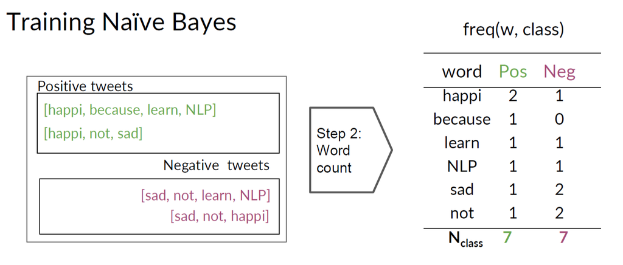

```python
dictionary=NB.freq_dic(Xtpn,Ytpn)
```

```
[================================================= ] 99%  prograss: 16434/16599
```

Example of some word:

```python
print('happy:', dictionary['happy'])
print('and:',dictionary['and'])
print('sad:',dictionary['sad'])
```

```
happy: [47, 0, 860]
and: [1635, 0, 1726]
sad: [399, 0, 6]
```

#### 'logprior_cal' function

The below screen shot shows the used formula to calculate the logprior parameter

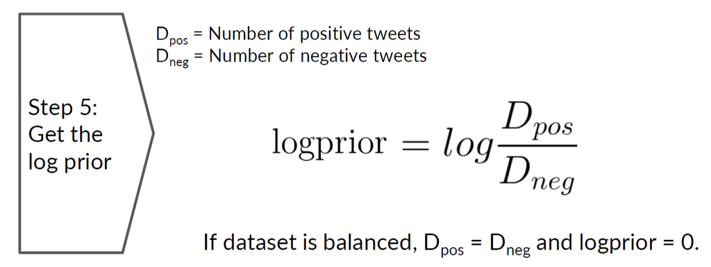

```python
NB.logprior_cal(Ytpn)
```

```
0.0893418665021887
```

#### 'Fit' function

In this function, the class calculate the lambda parameter of each word by the below formula

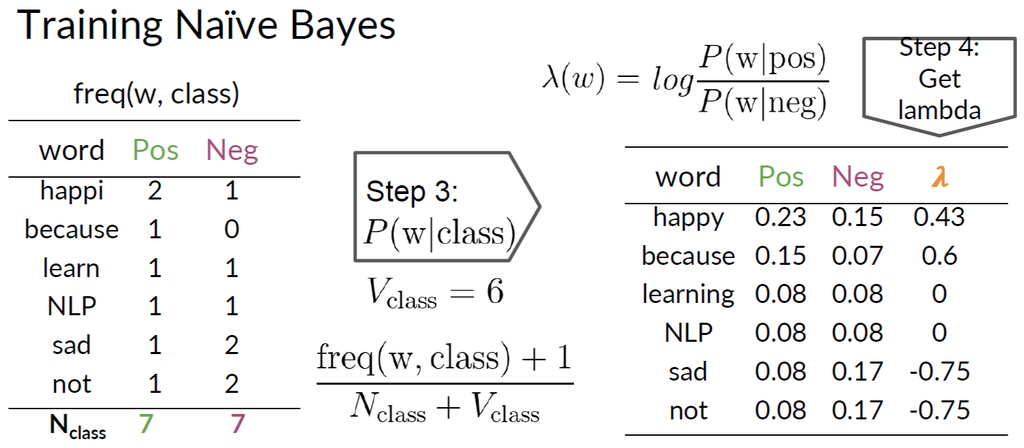

```python
NB.fit(Xtpn,Ytpn)
```

```
input processing
parameter calculation
[================================================= ] 99%  prograss: 16434/16599
```

```python
print('happy:', NB.lambd['happy'])
print('and:',NB.lambd['and'])
print('sad:',NB.lambd['sad'])
```

```
happy: 2.832923576256876
and: 0.00016164372102256408
sad: -4.099524315315633
```

### score_cal function

The score_cal function calculate the score of each input string by the below function:

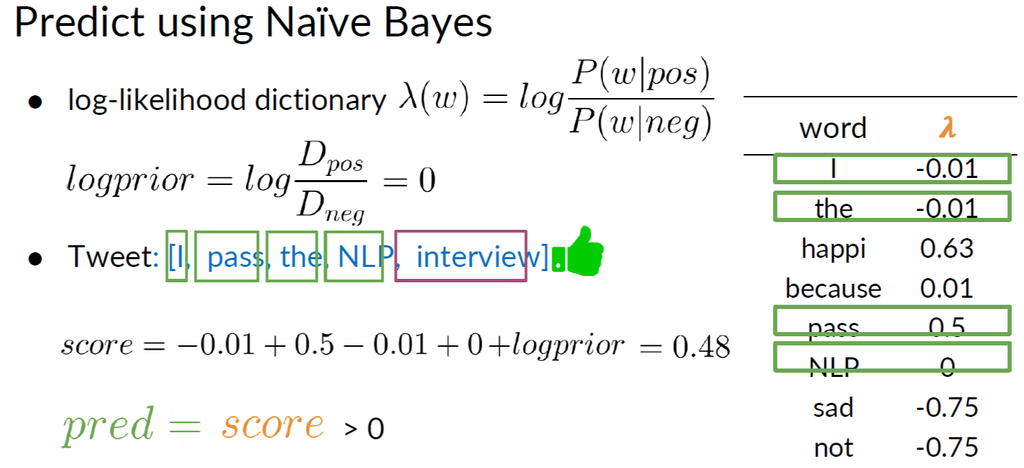

```python
SCORE=NB.score_cal(Xtpn)
```

```
[================================================= ] 99%  prograss: 16434/16599
```

Below a comparison between ontoup and the score arrays

```python
Ytpn[:10]
```

```
array([ 1,  1,  1, -1, -1, -1,  1, -1, -1,  1], dtype=int64)
```

```python
SCORE[:10]
```

```
array([ 8.53662728,  4.84330125,  5.20440492, -4.64133192, -3.38874383,
       -0.78712737,  4.10889886,  0.09927053, -8.91803343, 10.95823236])
```

### Predict function

This function use score function in the first function in the first time, and compare the values of score output with 0:

* score > 0 ===> prediction = 1 * score < 0 ===> prediction = -1

```python
Ytpn_hat=NB.predict(Xtpn)
```

```
[================================================= ] 99%  prograss: 16434/16599
```

The output

```python
Ytpn[:8]
```

```
array([ 1,  1,  1, -1, -1, -1,  1, -1], dtype=int64)
```

The predicted output

```python
Ytpn_hat[:8]
```

```
array([ 1,  1,  1, -1, -1, -1,  1,  1], dtype=int8)
```

### Accuracy function

This function calculate the accuracy between Y and Y_hat: Y_hat is the predicted output

```python
acc,accArr=NB.accuracy(Ytpn,Ytpn_hat)
```

The accArr is array with 1 if Y[i] = Y_hat[i] otherwise 0

```python
accArr[:8]
```

```
array([1, 1, 1, 1, 1, 1, 1, 0], dtype=int8)
```

acc parameter is the sum of right prediction divided by the total number of output

```python
acc
```

```
0.9360202421832641
```

### save_params Function

This function save the model parameters: Lambda dictionary and logprior parameter as npz file

```python
fileName='NB_parameters_test.npz'
NB.save_params(filename=fileName)
```

### read_params Function

This function load the model parameters: Lambda dictionary and logprior parameter form the npz file

Below we create an empty instance of Naive Bytes class, lambda dictionary and logprior are empty

```python
NB2=NaiveBytes()
print(NB2.lambd)
print(NB2.logprior)
```

```
None
None
```

After loading parameters, lambda dictionary and logprior aren't empty anymore

```python
NB2.read_paras(fileName)
print(NB2.lambd['happy'])
print(NB2.logprior)
```

```
2.832923576256876
0.0893418665021887
```

### The train/validation set accuracies

```python
Yvpn_hat=NB.predict(Xvpn)
```

```
[================================================= ] 99%  prograss: 1850/1868
```

```python
print( 'train set accuracy', NB.accuracy(Ytpn,Ytpn_hat)[0])
print( 'validation set accuracy', NB.accuracy(Yvpn,Yvpn_hat)[0])
```

```
train set accuracy 0.9360202421832641
validation set accuracy 0.8677730192719486
```

### New posts outside of the dataset

```python
X_new=['This is not a good day for me, I lose my car keys',
       'It is christmas day, It will be a great day with family',
       'I love the summer, I can travel everywhere',
       'The work in data science is great, we learn always new think',
       'I must buy a new car, the old cars are always a loss of many',
       "it wasn't a great day, but in the final minute i met the love of my life"]
```

##### Lower the text and remove punctuation

```python
Xnew=[x.lower().replace(',','').replace("'",'') for x in X_new]
Xnew
```

```
['this is not a good day for me i lose my car keys',
 'it is christmas day it will be a great day with family',
 'i love the summer i can travel everywhere',
 'the work in data science is great we learn always new think',
 'i must buy a new car the old cars are always a loss of many',
 'it wasnt a great day but in the final minute i met the love of my life']
```

##### Predict the output with the trained Naive Byes model

```python
Ynew_hat=NB2.predict(Xnew)
```

```python
Ynew_hat
```

```
array([-1,  1,  1,  1, -1,  1], dtype=int8)
```

##### Group the sentences and the predicted sentiment in a dataframe for more visibility

```python
New_txt=pd.DataFrame(X_new,columns=['text'])
```

```python
New_txt['sentiment']=Ynew_hat
```

##### Replace -1/1 by Negative/Positive words

```python
New_txt.sentiment=New_txt.sentiment.replace({-1:'Negative',1:'Positive'})
```

```python
print(New_txt.to_markdown())
```

```
|    | text                                                                     | sentiment   |
|---:|:-------------------------------------------------------------------------|:------------|
|  0 | This is not a good day for me, I lose my car keys                        | Negative    |
|  1 | It is christmas day, It will be a great day with family                  | Positive    |
|  2 | I love the summer, I can travel everywhere                               | Positive    |
|  3 | The work in data science is great, we learn always new think             | Positive    |
|  4 | I must buy a new car, the old cars are always a loss of many             | Negative    |
|  5 | it wasn't a great day, but in the final minute i met the love of my life | Positive    |
```

____

# LSTM (Long Short-Term Memory)

In this secotion, we will predict sentiment by LSTM RNN (Long Short-Term Memory), below a defenition of LSTM from Wikipedia  
"Long short-term memory (LSTM) is an artificial neural network used in the fields of artificial intelligence and deep learning. Unlike standard feedforward neural networks, LSTM has feedback connections. Such a recurrent neural network (RNN) can process not only single data points (such as images), but also entire sequences of data (such as speech or video). This characteristic makes LSTM networks ideal for processing and predicting data. For example, LSTM is applicable to tasks such as unsegmented, connected handwriting recognition, speech recognition, machine translation, speech activity detection, robot control, video games, and healthcare."

https://en.wikipedia.org/wiki/Long_short-term_memory

[figure not shown]

#### MaxLenght function

Is a function that calculate the maximum number of word in a sentence from an input as array

```python
def maxLen(Xp):
    m=0
    for x in Xp:
        m=np.max((len(x.split(' ')),m))
    return m
```

Below max number of word in a sentence in training set is 34

```python
maxLen(Xtpn)
```

```
34
```

### The embedding funciton of the inputs

The embeding is an operation that replace a text by vectors. if we have a sentence as "i love python", and e1, e2, e3 are the vectros of words 'i/love/python' in the GloVe dictonary, and the maximum number of words for each sentence is 5 for example. The embedding matrix of this sentence will be [e1,e2,e2,e0,e0], where e0 are zeros vectors to complet the number 5 br>  
In the actual project, we start with zeros verctors like: [e0,e0,e1,e2,e2]

In the general case, we use an embedding layer that convert index of words to vectors input, but in the below example, we decided to make the function manually to understand this operation.

```python
def embedding_input(Xp,maxlen=None):
    # calculate the maximum number of word in sentences array
    if maxlen is None:
        maxlen=maxLen(Xp)
    # m is the number of rows in input array
    m=len(Xp)
    # calculate the dimension of each word vector: actually n=50 for the glove.6b.50d.txt
    n=Glove['i'].shape[0]
    # initialize the output matrix by zeros
    Xvec=np.zeros((m,maxlen,n))
    # loop through each sentence in the input array
    for i in range(len(Xp)):
        # splite each sentence words: separator = space
        sent=Xp[i].split(' ')
        Lsent=len(sent)
        for j in range(Lsent):
            w=sent[j]
            # j+(maxlen-Lsent): is used to left 0 in the left side (not the right side)
            a=Xvec[i,j+(maxlen-Lsent),:]
            try:# try if the word is in Glove
                Xvec[i,j+(maxlen-Lsent),:]=Glove[w].tolist()
            except:
                pass
    return Xvec
```

#### Create an embedded input array

```python
Xt_emb=embedding_input(Xtpn)
```

```python
Xt_emb.shape
```

```
(16599, 34, 50)
```

```python
Xtpn[0]
```

```
'happy mother s day hugs'
```

##### the vectorization of the above sentence

```python
Xt_emb[0]
```

```
array([[ 0.      ,  0.      ,  0.      , ...,  0.      ,  0.      ,
         0.      ],
       [ 0.      ,  0.      ,  0.      , ...,  0.      ,  0.      ,
         0.      ],
       [ 0.      ,  0.      ,  0.      , ...,  0.      ,  0.      ,
         0.      ],
       ...,
       [-0.15234 ,  0.98085 ,  1.0065  , ...,  0.037843,  0.71744 ,
         0.32435 ],
       [ 0.11626 ,  0.53897 , -0.39514 , ..., -0.39062 , -0.10885 ,
         0.084513],
       [ 0.52489 ,  1.1061  , -0.34979 , ...,  0.14527 , -0.83897 ,
        -0.73191 ]])
```

#### Another way to vectorize the input text is the using of the Tokenizer [Just for information]

The below code is just for explanation

```python
from keras.preprocessing.text import Tokenizer
from keras_preprocessing.sequence import pad_sequences
max_fatures = 2000
tokenizer = Tokenizer(num_words=max_fatures, split=' ')
tokenizer.fit_on_texts(Xtpn)
X_sequ = tokenizer.texts_to_sequences(Xtpn)
X_sequ = pad_sequences(X_sequ)
X_sequ
```

```
array([[  0,   0,   0, ...,  10,  20, 552],
       [  0,   0,   0, ..., 147,  36, 335],
       [  0,   0,   0, ...,  10, 155,  53],
       ...,
       [  0,   0,   0, ...,   7,  44,  64],
       [  0,   0,   0, ...,  43,  60,  67],
       [  0,   0,   0, ...,   6,  42, 987]])
```

The output is a 2D array with word index

for more information , see the official [link](https://www.tensorflow.org/api_docs/python/tf/keras/preprocessing/text/Tokenizer)  
***The official definition of the Tokenizer***: This class allows to vectorize a text corpus, by turning each text into either a sequence of integers (each integer being the index of a token in a dictionary) or into a vector where the coefficient for each token could be binary, based on word count, based on tf-idf...  
By default, all punctuation is removed, turning the texts into space-separated sequences of words (words may include the ' character). These sequences are then split into lists of tokens. They will then be indexed or vectorized.

During the model building, we must add an Embedding layer by the below code  
**model.add(Embedding(max_fatures, embed_dim,input_length = X_sequ.shape[1]))**

This layer convert each index with the corresponding vector

#### The Kera Neural network model

```python
def MODEL(input_shape,output_shape):
    # input layer
    inp= Input(shape=input_shape ,dtype='float32')

    # LSTM layer with 128-dimensional hidden state
    X = LSTM(units = 128, return_sequences= True)(inp)
    # dropout with a probability of 0.5
    X = Dropout(rate=0.5)(X)

    # Propagate X trough another LSTM layer with 128-dimensional hidden state
    X = LSTM(units = 128, return_sequences= False)(X)
    # dropout with a probability of 0.5
    X = Dropout(rate=0.5)(X)

    # Propagate X through a Dense layer with softmax activation to get back a batch of 5-dimensional vectors.
    X = Dense(output_shape)(X)
    # Add a softmax activation
    X = Activation('softmax')(X)

    # Create Model instance which converts sentence_indices into X.
    model = Model(inputs=inp, outputs=X)
    return model
```

**We can also use the below method to define the model**  
from keras.models import Sequential  
input_shape=Xt_emb.shape[1:]  
output_shape=Yt_oh.shape[1]  
model2 = Sequential()  
model2.add(Input(shape=input_shape ,dtype='float32'))  
model2.add(LSTM(units = 128, return_sequences= True))  
model2.add(Dropout(rate=0.5))  
model2.add(LSTM(units = 128, return_sequences= False))  
model2.add(Dropout(rate=0.5))  
model2.add(Dense(output_shape,'softmax'))

#### Creat the embedded input array for the train/validation set

```python
maxlen=np.max((maxLen(Xtpn),maxLen(Xvpn)))
Xt_emb=embedding_input(Xtpn,maxlen)
Xv_emb=embedding_input(Xvpn,maxlen)
```

```python
Xt_emb.shape,Xv_emb.shape
```

```
((16599, 34, 50), (1868, 34, 50))
```

#### The One Hot encoding function

The below function encode the output with the one Hot methode.  
Example: y=['A','B','C','A'] => One_Hot(y)=[[1,0,0],[0,1,0],[0,0,1],[1,0,0]]]  
In the actual project, we propose to do it hundley, otherwise we can use the sklearn function below  
sklearn.preprocessing.OneHotEncoder

```python
def One_Hot_Encoding(Y):
    unique=np.unique(Y)
    Y2_onhot=np.zeros((len(Y),len(unique)))
    for i,x in enumerate (Y):
        j=np.argwhere(unique==x)[0][0]
        Y2_onhot[i,j]=1
    return Y2_onhot
```

##### Encode the train/validation output

```python
Yv_oh=One_Hot_Encoding(Yvpn+1)
Yt_oh=One_Hot_Encoding(Ytpn+1)
```

```python
Xtpn.shape,Ytpn.shape
```

```
((16599,), (16599,))
```

```python
Yvpn[:3]
```

```
array([ 1, -1, -1], dtype=int64)
```

```python
Yv_oh[:3]
```

```
array([[0., 1.],
       [1., 0.],
       [1., 0.]])
```

#### Create a LSTM model and compile it using ADAM optimizer

The model has 223 490 parameters

```python
model=MODEL(input_shape=Xt_emb.shape[1:],output_shape=Yt_oh.shape[1])
model.summary()
model.compile(loss='categorical_crossentropy', optimizer='adam', metrics=['accuracy'])
```

```
Model: "model_2"
_________________________________________________________________
 Layer (type)                Output Shape              Param #
=================================================================
 input_12 (InputLayer)       [(None, 34, 50)]          0

 lstm_20 (LSTM)              (None, 34, 128)           91648

 dropout_20 (Dropout)        (None, 34, 128)           0

 lstm_21 (LSTM)              (None, 128)               131584

 dropout_21 (Dropout)        (None, 128)               0

 dense_9 (Dense)             (None, 2)                 258

 activation_8 (Activation)   (None, 2)                 0

=================================================================
Total params: 223,490
Trainable params: 223,490
Non-trainable params: 0
_________________________________________________________________
```

##### Verification of the shape of inputs/outputs

```python
Xt_emb.shape, Yt_oh.shape,Xv_emb.shape, Yv_oh.shape
```

```
((16599, 34, 50), (16599, 2), (1868, 34, 50), (1868, 2))
```

#### Fit the model with 50 epochs

```python
history =model.fit(Xt_emb, Yt_oh, epochs = 50, batch_size = 32, shuffle=True,validation_data=(Xv_emb, Yv_oh))
```

#### Plot the accuracy/loss of the train/validation set

```python
history.history.keys()
```

```
dict_keys(['loss', 'accuracy', 'val_loss', 'val_accuracy'])
```

**Creat a History dataFrame and Add the word 'train' to the dedicated columns**

```python
History=pd.DataFrame.from_dict(history.history).rename(columns={'loss':'train_loss', 'accuracy':'train_accuracy'})
```

```python
History=History.rename(columns={'loss':'train_loss', 'accuracy':'train_accuracy'})
```

##### Plot accuracy/loss

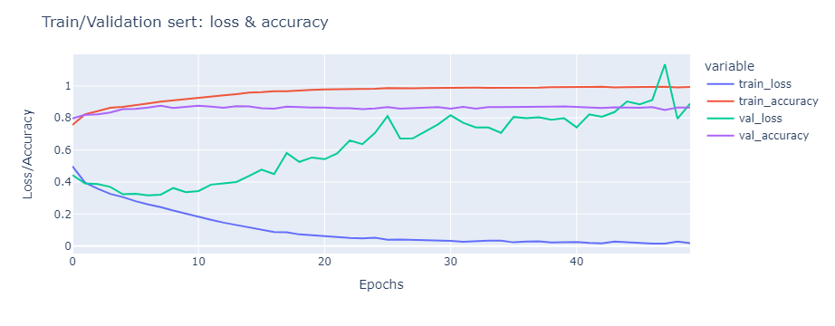

```python
fig=px.line(History)
fig.update_layout(title="Train/Validation sert: loss & accuracy", xaxis_title="Epochs", yaxis_title="Loss/Accuracy")
fig.show(renderer='vscode', width=800, height=300)
```

```python
History.columns
```

```
Index(['train_loss', 'train_accuracy', 'val_loss', 'val_accuracy'], dtype='object')
```

##### Plot only accuracy

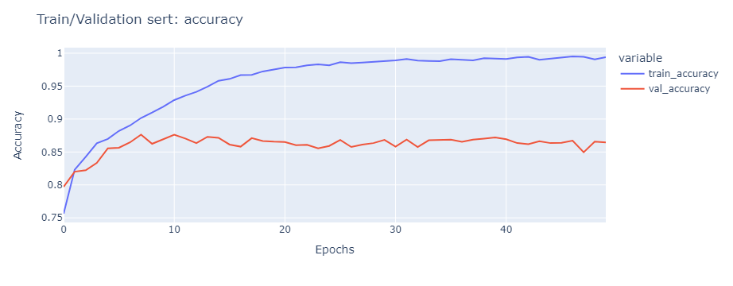

```python
fig=px.line(History,y=['train_accuracy','val_accuracy'])
fig.update_layout(title="Train/Validation sert: accuracy", xaxis_title="Epochs", yaxis_title="Accuracy")
fig.show(renderer='vscode', width=800, height=300)
```

Since the epoch 7, the validation accuracy stop increasing: so we can consider this epoch as the optimum valye to train the network

#### Predict the train/validation output

```python
Yt_hat= model.predict(Xt_emb)
Yv_hat= model.predict(Xv_emb)
```

##### Clean_output is a function that convert the soft max output to one hat output

This convertion is done by using argmax numpy method and One_Hot_Encoding: see above

```python
def Clean_output(Yt_hat):
    return One_Hot_Encoding(Yt_hat.argmax(axis=1))
```

```python
Yt_oh_hat=Clean_output(Yt_hat)
Yv_oh_hat=Clean_output(Yv_hat)
```

##### The onehot of the validation ouptut

```python
Yv_oh[:5]
```

```
array([[0., 1.],
       [1., 0.],
       [1., 0.],
       [0., 1.],
       [0., 1.]])
```

##### The predicted output of the validation set using LSTM model

```python
Yv_hat[:5]
```

```
array([[8.9244014e-01, 1.0755983e-01],
       [9.9999392e-01, 6.1291930e-06],
       [9.8429513e-01, 1.5704812e-02],
       [7.4519317e-06, 9.9999249e-01],
       [6.6542379e-06, 9.9999332e-01]], dtype=float32)
```

##### The predicted output of the validation set after using Clean_output

```python
Yv_oh_hat[:5]
```

```
array([[1., 0.],
       [1., 0.],
       [1., 0.],
       [0., 1.],
       [0., 1.]])
```

#### Verification of the accuracy calculation

**The accuracy calculated by the model fitting**

```python
History.val_accuracy.values[-1]
```

[output not shown]

**The accuracy with the mathematical formual**

[figure not shown]

```python
(Yv_oh_hat==Yv_oh).T[0].astype('int').sum()/len(Yv_oh)
```

```
0.8645610278372591
```

Model.fit value and the calculated value are close to each others

### New posts outside of the dataset

```python
X_new=['This is not a good day for me, I lose my car keys',
       'It is christmas day, It will be a great day with family',
       'I love the summer, I can travel everywhere',
       'The work in data science is great, we learn always new think',
       'I must buy a new car, the old cars are always a loss of many',
      "it wasn't a great day, but in the final minute i met the love of my life"]
```

##### Lower the text and remove punctuation

```python
Xnew=[x.lower().replace(',','').replace("'",'') for x in X_new]
Xnew
```

```
['this is not a good day for me i lose my car keys',
 'it is christmas day it will be a great day with family',
 'i love the summer i can travel everywhere',
 'the work in data science is great we learn always new think',
 'i must buy a new car the old cars are always a loss of many',
 'it wasnt a great day but in the final minute i met the love of my life']
```

```python
Xnew_emb=embedding_input(np.array(Xnew),maxlen)
Xnew_emb.shape,Xt_emb.shape
```

```
((6, 34, 50), (16599, 34, 50))
```

```python
Ynew_hat= model.predict(Xnew_emb)
```

```python
Ynew_hat
```

```
array([[9.9997735e-01, 2.2676420e-05],
       [2.3189379e-05, 9.9997675e-01],
       [1.0271043e-05, 9.9998975e-01],
       [6.5639033e-04, 9.9934357e-01],
       [9.8499727e-01, 1.5002729e-02],
       [2.2956953e-04, 9.9977046e-01]], dtype=float32)
```

```python
Clean_output(Ynew_hat)
```

```
array([[1., 0.],
       [0., 1.],
       [0., 1.],
       [0., 1.],
       [1., 0.],
       [0., 1.]])
```

```python
New_txt=pd.DataFrame(X_new,columns=['text'])
```

```python
New_txt['sentiment']=Clean_output(Ynew_hat).argmax(axis=1)
```

##### Replace /1 by Negative/Positive words

```python
New_txt.sentiment=New_txt.sentiment.replace({0:'Negative',1:'Positive'})
```

##### Group the sentences and the predicted sentiment in a dataframe for more visibility

```python
print(New_txt.to_markdown())
```

```
|    | text                                                                     | sentiment   |
|---:|:-------------------------------------------------------------------------|:------------|
|  0 | This is not a good day for me, I lose my car keys                        | Negative    |
|  1 | It is christmas day, It will be a great day with family                  | Positive    |
|  2 | I love the summer, I can travel everywhere                               | Positive    |
|  3 | The work in data science is great, we learn always new think             | Positive    |
|  4 | I must buy a new car, the old cars are always a loss of many             | Negative    |
|  5 | it wasn't a great day, but in the final minute i met the love of my life | Positive    |
```

### Save the model and the history

```python
model.save('model_31_05_2023.h5')
```

```python
History.to_parquet('History.parquet.gzip',compression='gzip')
```

```python
del(model);del(History)
```

### Load again the model and the history

```python
model = load_model('model_31_05_2023.h5')
```

```python
History=pd.read_parquet('History.parquet.gzip')
```

```python
History.tail(2)
```

[output not shown]

# Conclusion

In this project we compared two methods of sentiment analysis:

The prediction of Negative/Positive using a simple Naïve Bayes model

The prediction of Negative/Positive using a LSTM kera model

Below a table that resume the accuracy for both models

|  | Naive Bayes | LSTM |
| --- | --- | --- |
| Train set accurancy | 0.936 | 0.994 |
| Test/val set accurancy | 0.867 | 0.864 |

Theoretically we can reduce the model with increasing model size, and with increasing the train set

The variance in the other hand can be reduced with the increasing of the train set and with more regularization

As remark, the naive bayes model is very simple and fast comparing to the LSTM, so it can be a solution for some sample classification task